# Práctica 5. Datos anomalos

Tratamiento de Datos, Grado en Ciencia de Datos - UV

Carlos Santiago Martinez Torres

2025-04-09

# Introduccion y objetivos

El objetivo de esta práctica es comprobar si los conjuntos de datos con los que vamos a trabajar son consistentes y, por tanto, pueden ser empleados para realizar un análisis sin errores. Las observaciones contenidas en los datos pueden presentar diferentes tipos de inconsistencias, como valores perdidos (missing values), valores especiales y valores anómalos (outliers). Para evitar estas inconsistencias, estos datos deberán ser eliminados, corregidos o imputados. Siendo las etapas que pueden seguirse para obtener datos consistentes:

1. Detección de las inconsistencias.
2. Detectar el campo o campos que las generan y las dependencias entre ellos.
3. Corrección de errores.

Vamos a trabajar con el conjunto de datos dirty_iris, que ya conocemos, que contiene datos perdidos, valores especiales y anomalías de carácter numérico respecto a la distribución de los datos (dirty_iris.csv).

```r
# Limpiamos el entorno.
rm(list=ls())

# Cargamos las librerias.
library(tidyr)
library(dplyr)
library(ggplot2)
library(readr)
```

Cargamos el conjunto de datos con el que vamos a trabajar.

```r
dirty_iris <- read_csv("./data/dirty_iris.csv")
```

# Detección de inconsistencias en los datos

Por lo general, no hay un convenio o una representación común para indicar un dato perdido o incluso determinados valores especiales. En los siguientes ejercicios vamos a analizar cómo detectar inconsistencias presentes en los datos.

## Ejercicio 1: Inspección Visual

Inspecciona visualmente los valores del conjunto de datos (View) y ordena de mayor a menor y de menor a mayor cada variable para descubrir las diferentes inconsistencias que presenta el conjunto dirty_iris. Comenta los valores que te llamen la atención.

```r
#view(dirty_iris)

summary(dirty_iris)

lista_col <- colnames(dirty_iris)
#"Sepal.Length" "Sepal.Width"  "Petal.Length" "Petal.Width"  "Species"

for (n in lista_col) {
  r <- dirty_iris %>%
        arrange(desc(.data[[n]]))
  print(r)
}

for (n in lista_col) {
  r <- dirty_iris %>%
        arrange((.data[[n]])) # Por defecto es ascendentes
  print(r)
}
```

• Hay algunos datos identificados como inf.

• Cuando se ordena de menor a mayor, hay un valor de Sepal Width que es negativo.

• Ordenando, ya sea de mayor a menor o viceversa, hay alrededor de 2-3 valores anomalos.

## Ejercicio 2: Valores especiales

Visualizar los datos puede ser muy revelador, pero en general, especialmente para conjuntos de datos grandes, realizaremos este análisis de forma automática. Los valores especiales más comunes en R son:

• NA (not available): missing value o dato perdido (is.na)

• NULL (empty set): elemento nulo de longitud 0 (is.null)

• NaN (not a number): indeterminación con resultado desconocido (is.nan)

• Inf (infinite): valor numérico de valor infinito (is.infinite)

Nota: A parte de estas funciones, is.numeric comprueba si la variable es numérica; is.finite comprueba la existencia de cualquier valor especial en un vector numérico pero devuelve FALSE para variables de texto. Reemplaza, en todas las columnas numéricas del data frame dirty_iris, los valores que sean especiales (usando is.finite) o negativos por NA. Nota: Puedes reemplazar los valores para cada variable del data frame usando mutate con la función ifelse.

```r
sapply(dirty_iris, class) # Verificamos que si están las variables numéricas.
```

```
Sepal.Length  Sepal.Width Petal.Length  Petal.Width      Species
   "numeric"    "numeric"    "numeric"    "numeric"  "character"
```

```r
# Si la columna es numerica, verificamos que el valor es inf o menor a 0 y lo cambiamos.
for (n in lista_col) {
  if (is.numeric(dirty_iris[[n]])) {
    dirty_iris[[n]][!is.finite(dirty_iris[[n]]) | dirty_iris[[n]] < 0] <- NA
  }
}

summary(dirty_iris) # Verificamos que los datos hayan sido cambiados
```

```
  Sepal.Length     Sepal.Width      Petal.Length    Petal.Width       Species
 Min.   : 0.000   Min.   : 0.000   Min.   : 0.00   Min.   : 0.100   Length:150
 1st Qu.: 5.100   1st Qu.: 2.800   1st Qu.: 1.60   1st Qu.: 0.300   Class :character
 Median : 5.750   Median : 3.000   Median : 4.50   Median : 1.300   Mode  :character
 Mean   : 6.559   Mean   : 3.439   Mean   : 4.45   Mean   : 1.582
 3rd Qu.: 6.400   3rd Qu.: 3.300   3rd Qu.: 5.10   3rd Qu.: 1.900
 Max.   :73.000   Max.   :30.000   Max.   :63.00   Max.   :23.000
 NA's   :10       NA's   :18       NA's   :19      NA's   :13
```

## Ejercicio 3: Valores perdidos y observaciones completas

• Calcula el número y porcentaje de observaciones completas (muestras sin ningún dato perdido) empleando complete.cases (detecta todos los registros sin datos faltantes).

```r
# Todos los registros sin datos faltantes.
observaciones_completas <- complete.cases(dirty_iris)

# Número de observaciones completas
total_completos <- dim(dirty_iris[observaciones_completas, ])[1]

print(paste('Total observaciones completas :', total_completos))
```

```
[1] "Total observaciones completas : 94"
```

```r
# Para el porcentaje, tomamos los casos favorables entre todos los posibles, y multiplicamos por 100.
# Porcentaje de observaciones completas
porcentaje <- round(total_completos / dim(dirty_iris)[1], 2) * 100

print(paste('Porcentaje de observaciones completas :', porcentaje, '%'))
```

```
[1] "Porcentaje de observaciones completas : 63 %"
```

• Emplea después la función na.omit para quedarnos solo con las filas con datos completos en un nuevo data frame clean_iris.

```r
clean_iris <- dirty_iris %>%
                na.omit()

dim(clean_iris) # Comprobamos el nuevo df
```

```
[1] 94  5
```

```r
sum(is.na(clean_iris)) # Verificamos que no hayan valores NA.
```

```
[1] 0
```

# Detección de outliers univariante

Un outlier es una observación (o conjunto de observaciones) que no parecen consistentes con el resto de valores de esa variable. Por lo general, esas observaciones divergirán del patrón de comportamiento del resto de datos, es decir, presentarán una desviación respecto de la distribución de los datos. En esta sección, vamos a centrarnos en métodos de detección univariantes, así que, en los ejercicios, a modo de ejemplo, analizaremos solo la variable Petal.Width.

## Ejercicio 4: Estadísticos básicos

La presencia de outliers puede producir una gran influencia en caracterizaciones sencillas de los datos, como la media y la desviación típica.

Empleado la función summarise y across, calcula la media, la desviación típica, mediana, la median absolute deviation from the median (MADM) y el interquartile range (IQR) de las variables numéricas. Hazlo para el data frame con observaciones completas clean_iris (que no tiene NA pero tiene menos observaciones) y para el data frame con datos faltantes dirty_iris (que presenta muchos NA pero tiene todas las observaciones).

• Ten en cuenta que no se puede realizar un análisis estadístico con datos faltantes, pero en la mayoría de los casos se puede optar por no considerar dichos valores al realizar los cálculos (parámetro na.rm=TRUE).

• Para obtener el valor MADM, escribe una función madm(x) que sea robusta a la presencia de valores NA. Recuerda que el MADM se calcula como 1.4826 · median(|x − median|).

• Compara los resultados para los dos conjuntos en la variable Petal.Width.

```r
# Funcion que recibe una columna y evalua la desviacion absoluta de la mediana'median absolute deviation from the median'

madm <- function(v) {
  mediana <- median(v, na.rm=TRUE) # Cada vez que 'opera el vector', considera los na.
  valor <- 1.4826 * median(abs(v - mediana), na.rm=TRUE)
  return(valor)
}

# Analisis para df sin NA
info_clean <- clean_iris %>%
                summarise(across(.col = where(is.numeric),
                                 .fns = list (mean = mean, median = median, madm, IQR = IQR)))

# En este caso, se va a modificar la funcion base mean(), sd(), etc,
# ya que le pasamos un argumento extra que es na.rm...
# Por lo tanto, para aplicar la funcion, se debe llamar con ~

# Analisis para df con NA
info_dirty <- dirty_iris %>%
                summarise(across(.col = where(is.numeric),
                                 .fns = list (
                                   mean = ~ mean(., na.rm = TRUE),
                                   median = ~ median(., na.rm = TRUE),
                                   madm,
                                   IQR = ~ IQR(., na.rm = TRUE))))

# Comparamos los resultados
resultados <- rbind(info_clean, info_dirty)
resultados
```

```
# A tibble: 2 × 16
  Sepal.Length_mean Sepal.Length_median Sepal.Length_3 Sepal.Length_IQR Sepal.Width_mean
              <dbl>               <dbl>          <dbl>            <dbl>            <dbl>
1              6.35                5.8           1.04               1.3             3.30
2              6.56                5.75          0.964              1.3             3.44
# ℹ 11 more variables: Sepal.Width_median <dbl>, Sepal.Width_3 <dbl>, Sepal.Width_IQR <dbl>,
#   Petal.Length_mean <dbl>, Petal.Length_median <dbl>, Petal.Length_3 <dbl>,
#   Petal.Length_IQR <dbl>, Petal.Width_mean <dbl>, Petal.Width_median <dbl>, Petal.Width_3 <dbl>,
#   Petal.Width_IQR <dbl>
```

## Ejercicio 5: Métodos de detección de outliers

Escribe una función que detecte los outliers de un vector x para cada uno de los siguientes métodos de detección de outliers univariantes (todas las funciones tienen que ser robustas a la presencia de valores NA).

• Regla 3 sigma reglasigma(x): Considera que los datos siguen una distribución gaussiana. Datos típicos caracterizados por la media y la dispersión por la varianza. Valores por encima de 3 desviaciones típicas se consideran outliers.

• Identificador Hampel reglahampel(x): Utiliza estimadores robustos y no presupone que los datos siguen una distribución gaussiana. Datos típicos caracterizados por la mediana y la dispersión por la median absolute deviation from the median (MADM). Valores por encima de 3 MADM se consideran outliers.

• Regla boxplot reglaboxplot(x): A partir de los datos se calcula su diagrama de caja (boxplot) y se definen como datos típicos superiores hasta el cuartil 75%, xs; datos típicos inferiores hasta el cuartil 25%, xi; y la dispersión se define como el rango intercuartílico (IQR = xs − xi). Valores por encima de xs + 1.5 · IQR o por debajo de xi − 1.5 · IQR se consideran outliers. Usa la función quantile para calcular los cuartiles.

• Percentiles reglapercentil(x): Cualquier valor que esté fuera del rango del percentil 5% y 95% se puede considerar como atípico. Usa la función quantile para calcular los percentiles.

```r
# Funcion para Regla 3 sigma
reglasigma <- function(v){
  media <- mean(v, na.rm=TRUE)
  sigma <- sd(v, na.rm=TRUE)
  return (v < ((media - (3*sigma)) | (media + (3*sigma))))
}


# Funcion para Identificador Hampel
reglahampel <- function(v) {
  mediana <- median(v, na.rm = TRUE)
  madm <- madm(v)
  return((v < (mediana - (3 * madm)) | (v > (mediana + (3 * madm)))))
}


# Funcion Regla boxplot
reglaboxplot <- function(v){
  xi <- quantile(v, probs =  0.25, na.rm=TRUE)
  xs <- quantile(v, probs =  0.75, na.rm=TRUE)
  iqr <- xs - xi
  return((v < (xi - (1.5 * iqr))) | (v > (xs + (1.5 * iqr))))
}

# Funcion Percentiles
reglapercentil <- function(v) {
  xi <- quantile(v, probs = 0.05, na.rm=TRUE)
  xs <- quantile(v, probs = 0.95, na.rm=TRUE)
  return((v < xi) | (v > xs))
}
```

## Ejercicio 6: Detección de outliers

Utiliza la función mutate y across para identificar los outliers en la variable Petal.Width con todos los métodos de detección de outliers implementados. Genera una columna nueva para cada método. Nota: podría extenderse la aplicación a todas las variables numéricas usando también mutate, across y where.

```r
dirty_iris <- dirty_iris %>%
  mutate(across(.cols = Petal.Width,
                .fns = list ( reglasigma = reglasigma,
                              reglahampel = reglahampel,
                              reglaboxplot = reglaboxplot,
                              reglapercentil = reglapercentil)))

clean_iris <- clean_iris %>%
  mutate(across(.cols = Petal.Width,
                .fns = list ( reglasigma = reglasigma,
                              reglahampel = reglahampel,
                              reglaboxplot = reglaboxplot,
                              reglapercentil = reglapercentil)))
```

## Ejercicio 7: Comparativa de los métodos de detección de outliers

En los métodos de detección de outliers analizados, examina los resultados comparando:

• Número de outliers detectados por método.

```r
dirty_iris %>%
  select(contains('regla')) %>%
  summarise(across(everything(), sum, na.rm = TRUE))
```

```
# A tibble: 1 × 4
  Petal.Width_reglasigma Petal.Width_reglahampel Petal.Width_reglaboxplot Petal.Width_reglapercentil
                   <int>                   <int>                    <int>                      <int>
1                     45                       3                        3                         11
```

```r
clean_iris %>%
  select(contains('regla')) %>%
  summarise(across(everything(), sum, na.rm = TRUE))
```

```
# A tibble: 1 × 4
  Petal.Width_reglasigma Petal.Width_reglahampel Petal.Width_reglaboxplot Petal.Width_reglapercentil
                   <int>                   <int>                    <int>                      <int>
1                     32                       3                        3                          9
```

• Los valores etiquetados como outliers (ordenados de menor a mayor).

```r
dirty_iris %>%
  filter(TRUE) %>%
  arrange(Petal.Width) %>%
  head()
```

```
# A tibble: 6 × 9
  Sepal.Length Sepal.Width Petal.Length Petal.Width Species Petal.Width_reglasigma
         <dbl>       <dbl>        <dbl>       <dbl> <chr>   <lgl>
1          4.9         3.6         NA           0.1 setosa  TRUE
2          4.9         3.1          1.5         0.1 setosa  TRUE
3          4.8         3            1.4         0.1 setosa  TRUE
4          4.3         3            1.1         0.1 setosa  TRUE
5          5.2         4.1          1.5         0.1 setosa  TRUE
6          5.3        NA           NA           0.2 setosa  TRUE
# ℹ 3 more variables: Petal.Width_reglahampel <lgl>, Petal.Width_reglaboxplot <lgl>,
#   Petal.Width_reglapercentil <lgl>
```

```r
clean_iris %>%
  filter(TRUE) %>%
  arrange(Petal.Width) %>%
  head()
```

```
# A tibble: 6 × 9
  Sepal.Length Sepal.Width Petal.Length Petal.Width Species Petal.Width_reglasigma
         <dbl>       <dbl>        <dbl>       <dbl> <chr>   <lgl>
1          4.9         3.1          1.5         0.1 setosa  TRUE
2          4.8         3            1.4         0.1 setosa  TRUE
3          4.3         3            1.1         0.1 setosa  TRUE
4          5.2         4.1          1.5         0.1 setosa  TRUE
5          4.8         3.1          1.6         0.2 setosa  TRUE
6          4.7         3.2          1.3         0.2 setosa  TRUE
# ℹ 3 more variables: Petal.Width_reglahampel <lgl>, Petal.Width_reglaboxplot <lgl>,
#   Petal.Width_reglapercentil <lgl>
```

# Imputación de datos

## Ejercicio 8: Representación gráfica

Representa gráficamente los datos de Petal.Width (distribución de puntos en el eje y) para todas las reglas de detección implementadas (repartidas en el eje x) mostrando los valores identificados como típicos y los identificados como outliers en diferente color. Usa la función pivot_longer para poder agrupar por reglas y colorear los outliers fácilmente.

Nota: usa en geom_point con la opción position=‘jitter’ para mejrar la legibilidad del gráfico.

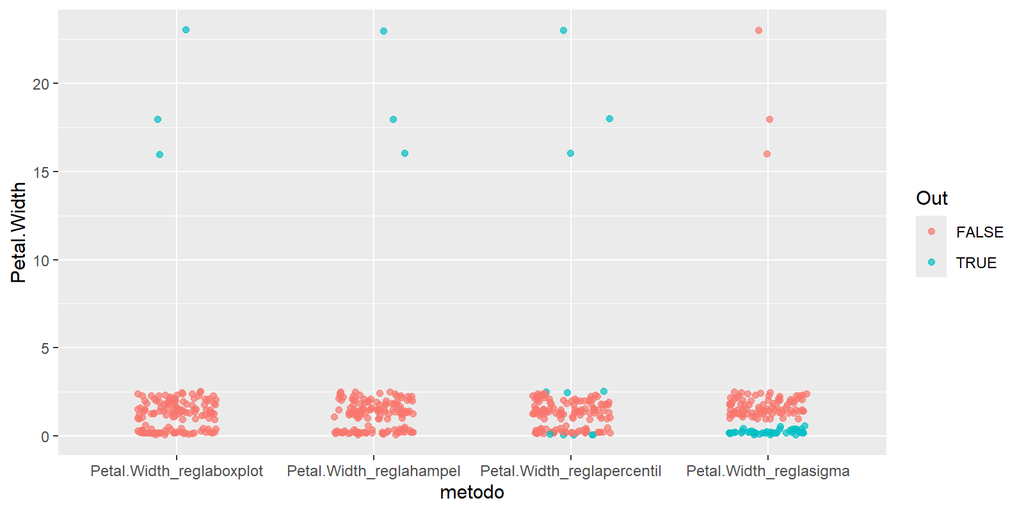

```r
dirty_iris %>%
  pivot_longer(cols = contains('regla'),
               names_to = "metodo",
               values_to = "Out") %>%
  filter(!is.na(Petal.Width)) %>%
  ggplot(aes(x = metodo, y = Petal.Width, colour = Out)) +
  geom_point(position = position_jitter(width = 0.2), alpha = 0.7)
```

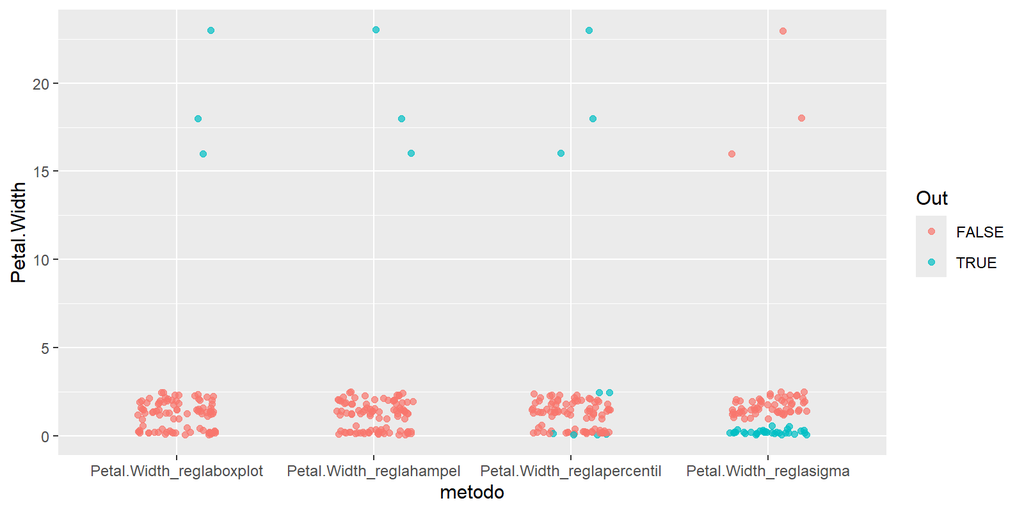

```r
clean_iris %>%
  pivot_longer(cols = contains('regla'),
               names_to = "metodo",
               values_to = "Out") %>%
  filter(!is.na(Petal.Width)) %>%
  ggplot(aes(x = metodo, y = Petal.Width, colour = Out)) +
  geom_point(position = position_jitter(width = 0.2), alpha = 0.7)
```

## Ejercicio 9: Imputación de datos perdidos con estadísticos básicos

La opción más sencilla es imputar con un valor estimado de los valores conocidos (por ejemplo, con la media, la mediana, o la moda). Se puede realizar una imputación generalizada (usando todos los valores de la variable) o una imputación a partir de casos similares (la estimación se realiza teniendo en cuenta otra variable):

• Imputa los missing data en Petal.Width empleando la media. Nota: Puedes reemplazar los valores vacios usando mutate con ifelse creando una nueva variable Petal.Width1.

```r
dirty_iris <- dirty_iris %>%
  mutate(Petal.Width1 = ifelse(is.na(Petal.Width),
                               mean(Petal.Width, na.rm = TRUE),
                               Petal.Width))
```

• Imputa los missing data en Petal.Width empleando en esta ocasión la media para cada tipo de Species (usar group_by y mutate) creando una nueva variable Petal.Width2.

```r
dirty_iris <- dirty_iris %>%
  group_by(Species) %>%
  mutate(Petal.Width2 = ifelse(is.na(Petal.Width),
                               mean(Petal.Width, na.rm = TRUE),
                               Petal.Width))
```

## Ejercicio 10: Representación gráfica

Vamos a comparar ahora los dos métodos de imputación gráficamente eliminando los outliers para una mejor visualización.

• Recalcula las reglas de identificación de outliers (Ejercicio 6) para la nueva variable Petal.Width2.

• Representa los dos tipos de imputación empleados en un gráfico de dispersión (Petal.Width1 vs. Petal.Width2) eliminando los outliers identificados con la regla reglapercentil y poniendo en diferente color los datos originales y los imputados.

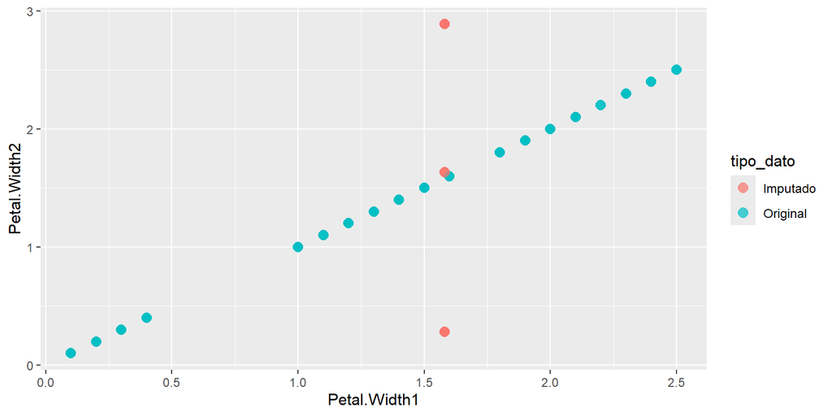

```r
dirty_iris <- dirty_iris %>%
  mutate(outlier_percentil = reglapercentil(Petal.Width2)) %>%
  mutate(tipo_dato = ifelse(is.na(Petal.Width), "Imputado", "Original"))

dirty_iris %>%
  filter(outlier_percentil == FALSE) %>%
  ggplot(aes(x = Petal.Width1, y = Petal.Width2, color = tipo_dato)) +
  geom_point(size = 3, alpha = 0.7)
```